# Informe

# **S2 Análisis del impacto del estrés en el rendimiento académico de los estudiantes de UTEC que cursaron “Cálculo de una variable”**

### ÍNDICE

- Introducción
  - Relevancia
  - Objetivos
  - Contexto
- Datos
  - Recolección de datos
  - Población, muestra y muestreo
  - Variables
  - Limpieza de base de datos
- Análisis descriptivo

## **INTRODUCCIÓN**

### **RELEVANCIA**

La selección del tema se basa en que el estrés es un problema que afecta la salud de las personas en el día a día. Esta es una reacción nuestra ante eventos o situaciones difíciles y con el paso del tiempo puede afectar a nuestro organismo. Durante la etapa universitaria los estudiantes estamos expuestos a distintas situaciones que pueden ser estresantes, por ejemplo, llevar demasiados cursos en el ciclo, cursos complicados en un mismo semestre, sobrecarga de tareas o exámenes, etc.

En nuestro caso queremos analizar el curso de cálculo de una variable porque consideramos que es uno de los que más nivel de estrés genera en los alumnos que recién empiezan su carrera universitaria en UTEC por el nivel de exigencia que tiene. De esta forma buscamos entender cómo este puede afectar en el rendimiento académico de los distintos universitarios, ya que no todas las personas reaccionan de la misma manera a estímulos estresantes; es decir, conocer qué nivel de estrés llegaron a sentir los alumnos del curso e identificar cuáles fueron las causas que llevaron a tales niveles de estrés.

### **OBJETIVOS**

**Objetivo general**  
Analizar el impacto del estrés en el rendimiento académico de los estudiantes de UTEC que cursaron cálculo de una variable

**Objetivos específicos**

- Determinar los niveles de estrés producidos por el curso de cálculo de una variable en diversos estudiantes de UTEC.
- Identificar las causas más y menos comunes que producen estrés en los estudiantes que han cursado o se encuentran cursando el curso de cálculo de una variable.
- Corroborar si existe algún tipo de relación entre el estrés y el rendimiento académico en los estudiantes de UTEC.

### **CONTEXTO**

Se sabe que la mayoría de los estudiantes que ingresan a la universidad tienen que llevar de manera obligatoria el curso de “Cálculo de una variable”. Pero como en todo curso, no todos lo pasan a la primera, por lo que este estudio nos sirve para ver cuáles son las notas con la que los alumnos pasan el curso, cuántas veces lo han llevado, qué tan estresante se puede volver este para los alumnos y qué tanto tiempo le dedican a la semana a este curso que es la base de la carrera de muchos.

## **DATOS**

```r
rm(list = ls())
library(readr)
datos <- read_csv("datos.csv")
library(knitr)
```

### **PROCESO DE RECOLECCIÓN DE DATOS**

Para la recolección realizamos encuestas en la universidad. Creamos un formulario en Google Forms y enviamos el link a diferentes grupos para poder obtener información necesaria para el proyecto por parte de alumnos de distintos ciclos que ya hayan llevado el curso o lo estuvieran cursando. También se buscó hacer la encuesta de manera presencial, esto para poder alcanzar un número mayor de encuestados en un tiempo más corto, es por ello que una de las estrategias fue dar un dulce de premio a quienes nos apoyaron. Se realizó de esta manera, ya que se buscaba tener información de los alumnos de la universidad; es decir, nuestra población solo son alumnos de UTEC.

## **VARIABLES**

```r
library(chron)
#Eliminación de columnas inutiles
datos <- datos[, !(names(datos) %in% c("Marca temporal", "Ingresa tu correo institucional", "Ingresa tu número de teléfono (opcional)" ))]
#Cambio de nombre de las columnas
colnames(datos) <- c("Carrera","LlevoCalculo","Si,Intento","No,razon","Promedio","Estrésante","AfectaNotas","NivelEstres","CausaEstres","Desestresamiento","AprobarEstrategia","HorasEstudios","HorasSueño","HorasLibres","ApoyoDocente","Recomendaciones")
```

## **LIMPIEZA DE DATOS**

Se adaptó la respuesta de la variable *“Si, intento”* para ser una ayuda visual en los gráficos, pues no es una variable que tomaríamos como entera.

```r
#Adaptación de datos
for (i in seq_along(datos$`Si,Intento`)) {
  if (datos$`Si,Intento`[i] =="1") {
    datos$`Si,Intento`[i] <- "Primer Intento"
  }
  else if (datos$`Si,Intento`[i] =="2") {
    datos$`Si,Intento`[i] <- "Segundo Intento"
  }
  else if (datos$`Si,Intento`[i] =="3") {
    datos$`Si,Intento`[i] <- "Tercer Intento"
  }

}
```

Después, las preguntas que eran de opción múltiple en el formulario se adaptaron para que la variable de sea de tipo lista, así su contabilización sera más exacta para el estudio realizado. Además en la pregunta del formulario incluimos una opción que podía ser rellenada con texto, al ser una cantidad insignificantes en las que se relleno decidimos incluir todas esas respuestas en una respuesta conjunta llamada **“Otros”**.

- Adaptación para *CausaEstres:*

```r
datos$CausaEstres <- strsplit(datos$CausaEstres, split=";")
OpcionesEstres <- c("Las actividades de aula","Las actividades grupales","Las tareas semanales","El proyecto","Los exámenes parcial y final","La mala explicación del profesor","Los temas tan confusos","La gran cantidad de evaluaciones","Ninguno (todo fue fácil)"
)
for (i in seq_along(datos$CausaEstres)) {
  for (j in seq_along(datos$CausaEstres[[i]])) {
    if (!datos$CausaEstres[[i]][j] %in% OpcionesEstres) {
      datos$CausaEstres[[i]][j] <- "Otros"
    }
  }
}
```

- Adaptación para *Desestresamiento:*

```r
datos$Desestresamiento <- strsplit(datos$Desestresamiento, split=";")
OpcionesDesestresamiento <- c("Deporte","Escuchar música","Videojuegos","Tomarte el día libre","Ayuda psicológica","Pedir ayuda a tus compañeros","Estudiar otro curso","Maldecir al profesor y al curso","Dormir")

for (i in seq_along(datos$Desestresamiento)) {
  for (j in seq_along(datos$Desestresamiento[[i]])) {
    if (!datos$Desestresamiento[[i]][j] %in% OpcionesDesestresamiento) {
      datos$Desestresamiento[[i]][j] <- "Otros"
    }
  }
}
```

- Adaptación para *AprobarEstrategia:*

```r
datos$AprobarEstrategia <- strsplit(datos$AprobarEstrategia,split = ";")
OpcionesEstrategia <- c("Mentorías","Asesorías","Libros de la biblioteca","Estudios grupales","Profesor particular","Solo estudié lo aprendido en clase")

for (i in seq_along(datos$AprobarEstrategia)) {
  for (j in seq_along(datos$AprobarEstrategia[[i]])) {
    if (!datos$AprobarEstrategia[[i]][j] %in% OpcionesEstrategia) {
      datos$AprobarEstrategia[[i]][j] <- "Otros"
    }
  }
}
```

- Adaptación para *Recomendaciones:*

```r
datos$Recomendaciones <- strsplit(datos$Recomendaciones, split = ";")
OpcionesRecomendaciones <- c("Colocar el 100% de tu esfuerzo desde la primera semana","Estudiar de antemano el curso","Buscar ayuda de estudiantes de ciclos superiores","Orar","Rendirse","No recomendar nada (el curso es fácil no hay necesidad de preparación)")

for (i in seq_along(datos$Recomendaciones)) {
  for (j in seq_along(datos$Recomendaciones[[i]])) {
    if (!datos$Recomendaciones[[i]][j] %in% OpcionesRecomendaciones) {
      datos$Recomendaciones[[i]][j] <- "Otros"
    }
  }
}
```

Por último, se dividió en dos grupos los datos que hemos obtenido, entre los que llevaron el curso de Cálculo de una variable y los que no lo llevaron. Además, añadimos que si respondiste que no llevaste el curso, pero ponías la razón “me retiré”, si cuente como que has llevado el curso:

```r
datos$LlevoCalculo[datos$`No,razon` == "Me retiré"] <- "Si"
datoSI <- datos[datos$LlevoCalculo == "Si", ]
datoNo <- datos[datos$LlevoCalculo != "Si", ]
datoNo <- subset(datoNo,select = c("Carrera","LlevoCalculo","No,razon"))
```

## **ANÁLISIS DESCRIPTIVO**

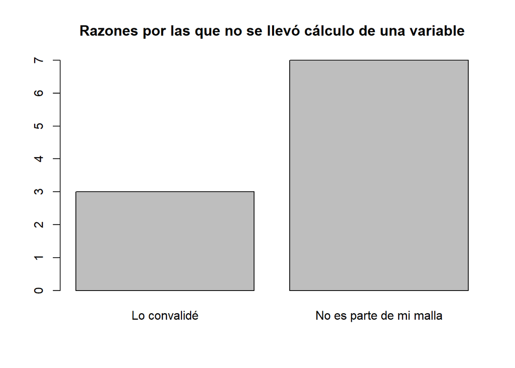

```r
#Gráfico de por qué no se llevó cálculo
RzNoCalc <- table(datoNo$`No,razon`)
barplot(RzNoCalc, main = "Razones por las que no se llevó cálculo de una variable")
```

```r
kable(RzNoCalc)
```

| Var1 | Freq |
| --- | --- |
| Lo convalidé | 3 |
| No es parte de mi malla | 7 |

La variable **No,razon** la utilizamos para conocer las razones por las que las personas no llevaron el curso de Cálculo de una Variable. En este caso el 70% de los que no llevaron el curso fue que no lo hicieron porque no estaba dentro de su malla, mientras que el 30% de los que no llevaron el curso mencionaron que lo convalidaron.

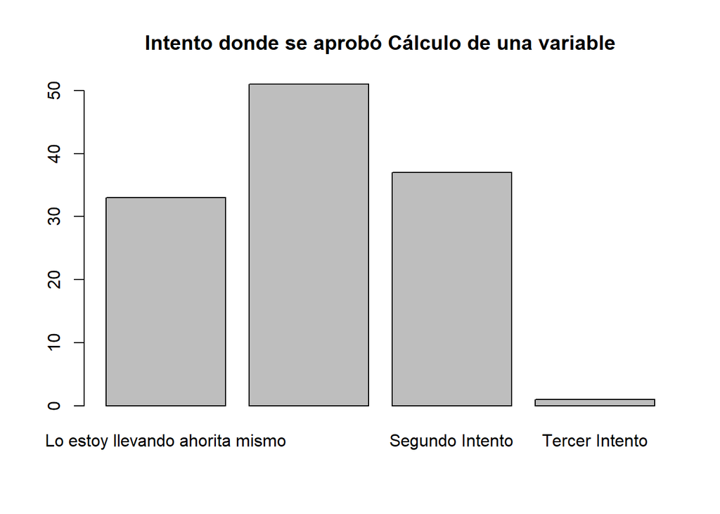

```r
SiInCalc <- table(datoSI$`Si,Intento`)
barplot(SiInCalc, main = "Intento donde se aprobó Cálculo de una variable",)
```

```r
kable(SiInCalc)
```

| Var1 | Freq |
| --- | --- |
| Lo estoy llevando ahorita mismo | 33 |
| Primer Intento | 51 |
| Segundo Intento | 37 |
| Tercer Intento | 1 |

Con la variable **Si,Intento** buscamos definir en qué intento se pasó el curso de cálculo de una variable. Notamos que el 41.8% lo aprobó al primer intento. Por otro lado un 30.3% lo hizo en un segundo intento; un 0.8% lo hizo en el tercer intento y finalemte el 27.1% de ellos lo están llevando el presente ciclo académico.

De esta manera buscamos conocer si un gran porcentaje de estudiantes aprueba el curso en un primer intento. Con esto podemos ver que menos del 50% lo hizo; es decir, el nivel de dificultad presentado en el curso fue considerable.

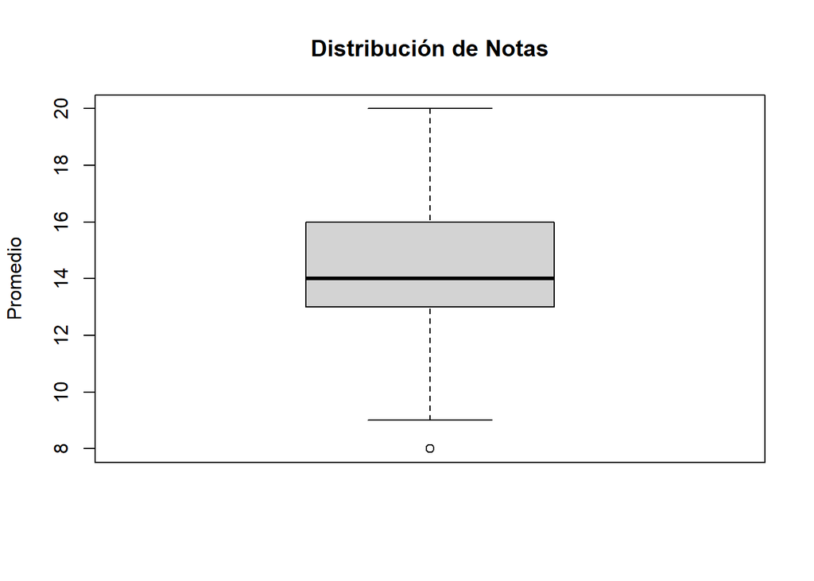

```r
#Promedio de las notas
valores_no_numericos <- grepl("[^0-9.]+", datoSI$Promedio)
datoSIs <- subset(datoSI, !valores_no_numericos)
datoSIs$Promedio <- as.numeric(datoSIs$Promedio)
boxplot(datoSIs$Promedio, main = "Distribución de Notas", ylab = "Promedio")
```

```r
cat("Promedio: ", mean(datoSIs$Promedio),"\n")
```

```
## Promedio:  14.52062
```

```r
cat("Minimo: ", min(datoSIs$Promedio),"\n")
```

```
## Minimo:  8
```

```r
cat("Maximo: ", max(datoSIs$Promedio),"\n")
```

```
## Maximo:  20
```

```r
P_cuartiles <- quantile(datoSIs$Promedio, probs = c(0.25, 0.5, 0.75))
cat("Primer cuartil (Q1):", P_cuartiles[1], "\n")
```

```
## Primer cuartil (Q1): 13
```

```r
cat("Mediana:", P_cuartiles[2], "\n")
```

```
## Mediana: 14
```

```r
cat("Tercer cuartil (Q3):", P_cuartiles[3], "\n")
```

```
## Tercer cuartil (Q3): 16
```

Observamos valores máximos y mínimos de los promedios finales del curso de diversos estudiantes. Notamos que la nota máxima obtenida por los alumnos fue de 20, mientras que la menor nota fue de 08. En general, tenemos un promedio de notas de 14.52 y una mediana de notas de 14. Por otro lado, en el cuartil 1 (Q1), es decir, el 25% de las notas más bajas, tienen como máxima nota 13; mientras que, el cuartil 3 (Q3) que representa el 25% de las notas más altas, tiene como nota mínima de 16.

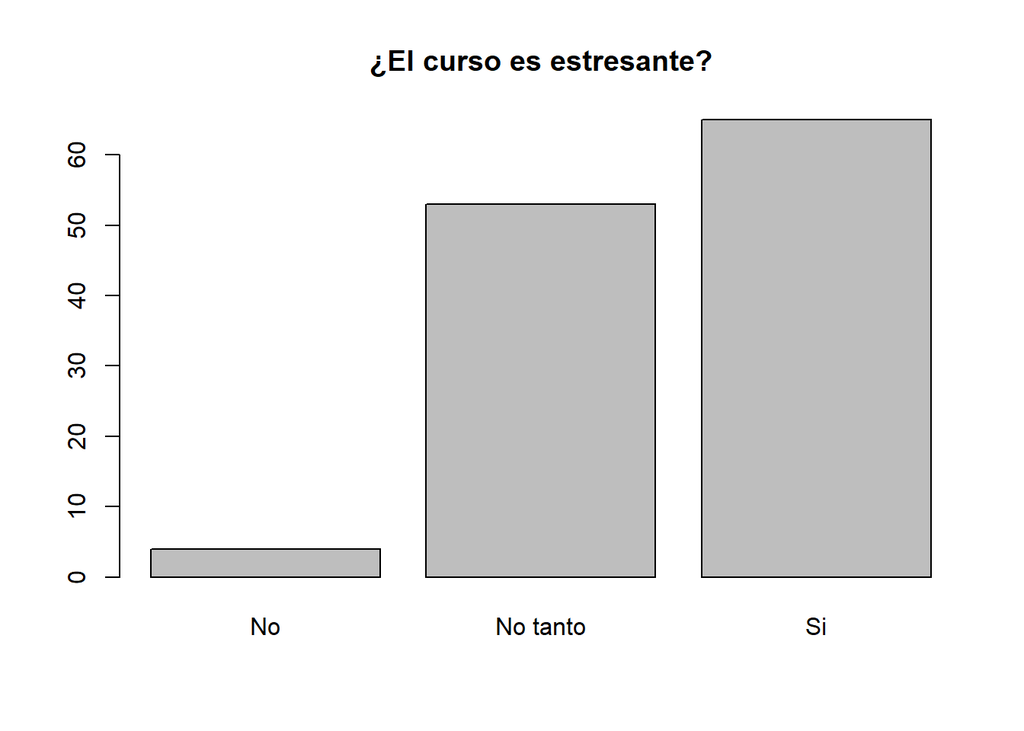

```r
Estr<-table(datoSI$Estrésante)
barplot(Estr, main = "¿El curso es estresante?")
```

```r
kable(Estr)
```

| Var1 | Freq |
| --- | --- |
| No | 4 |
| No tanto | 53 |
| Si | 65 |

Con la variable **Estresante** buscamos determinar si los alumnos consideran el curso estresante. De esta manera, un poco más del 50% manifestó que el curso sí genera un nivel de estrés, mietras que solo un 3% no lo considera así. También tenemos un 43.4% que los considera medianamente estresante. Buscamos identificar esto para poder determinar el los niveles de estrés generados por el curso.

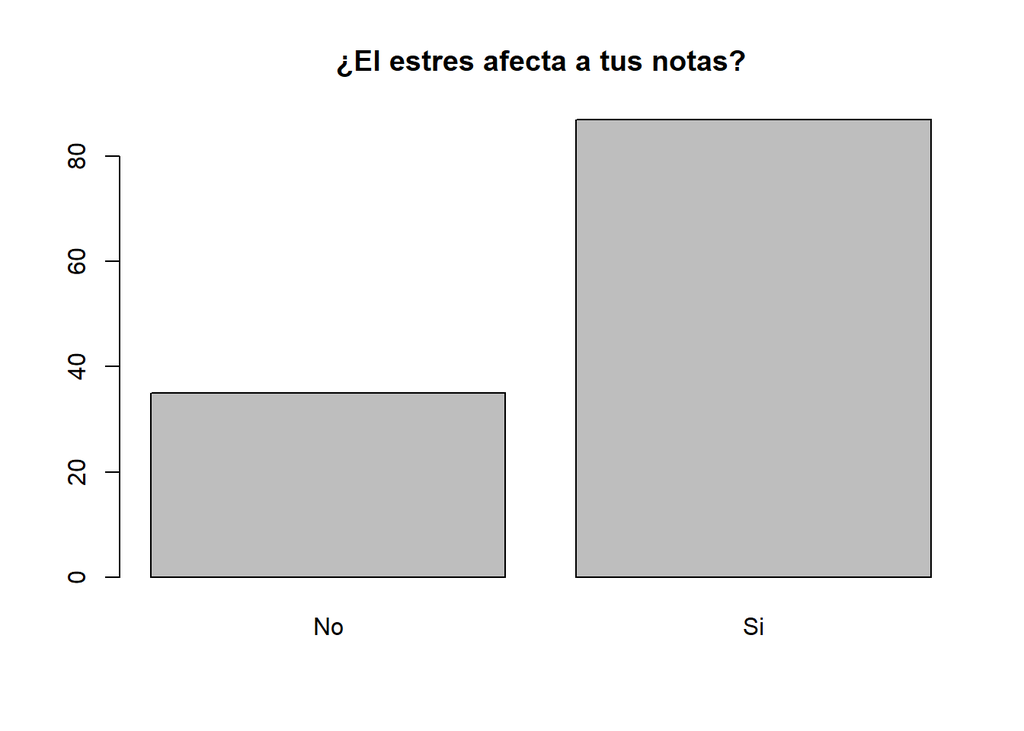

```r
AfNt <- table(datoSI$AfectaNotas)
barplot(AfNt, main = "¿El estres afecta a tus notas?")
```

```r
kable(AfNt)
```

| Var1 | Freq |
| --- | --- |
| No | 35 |
| Si | 87 |

Con la variable **AfectaNotas** queremos determinar si las notas de los alumnos se ve afectada por el estrés generado por el curso. Aquí observamos que el 71.3% de los encuestados manifestó que sus notas se vieron afectadas por el estrés. Esto quiere decir que sí existe una relación entre estrés generado y promedio final; ya que tenemos un número grande de encuestados que así lo manifestó.

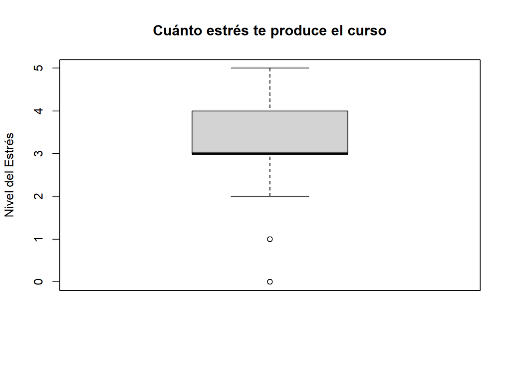

```r
boxplot(datoSI$NivelEstres, main = "Cuánto estrés te produce el curso", ylab = "Nivel del Estrés")
```

```r
cat("Promedio: ", mean(datoSI$NivelEstres),"\n")
```

```
## Promedio:  3.327869
```

```r
cat("Minimo: ", min(datoSI$NivelEstres),"\n")
```

```
## Minimo:  0
```

```r
cat("Maximo: ", max(datoSI$NivelEstres),"\n")
```

```
## Maximo:  5
```

```r
NE_cuartiles <- quantile(datoSI$NivelEstres, probs = c(0.25, 0.5, 0.75))
cat("Primer cuartil (Q1):", NE_cuartiles[1], "\n")
```

```
## Primer cuartil (Q1): 3
```

```r
cat("Mediana:", NE_cuartiles[2], "\n")
```

```
## Mediana: 3
```

```r
cat("Tercer cuartil (Q3):", NE_cuartiles[3], "\n")
```

```
## Tercer cuartil (Q3): 4
```

En este diagrama de caja podemos observar el nivel de estrés producido por el curso. Tenemos una media de nivel de 3 de una escala de 0 a 5, donde 0 representa nada de estrés y 5 representa muy alto estrés. Esto quiere decir que el curso genera un nivel de estrés moderado en los estudiantes de UTEC y que por esta razón se manifestaba que sus notas se ven afectadas.

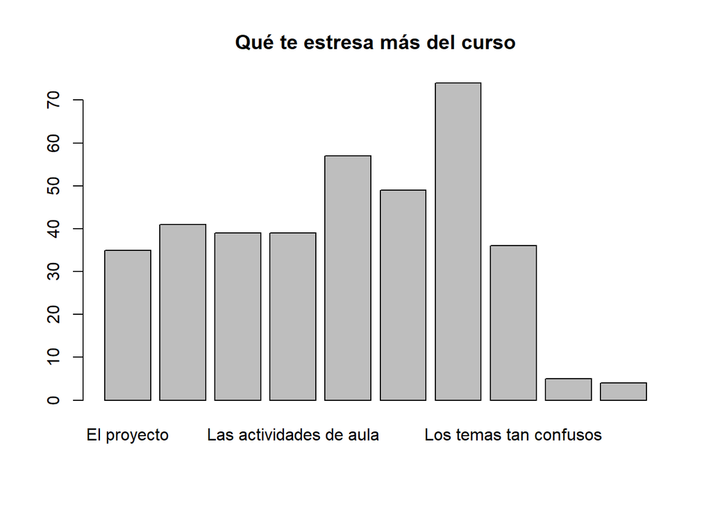

```r
barplot(table(unlist(datoSI$CausaEstres)),main = "Qué te estresa más del curso")
```

```r
kable(table(unlist(datoSI$CausaEstres)))
```

| Var1 | Freq |
| --- | --- |
| El proyecto | 35 |
| La gran cantidad de evaluaciones | 41 |
| La mala explicación del profesor | 39 |
| Las actividades de aula | 39 |
| Las actividades grupales | 57 |
| Las tareas semanales | 49 |
| Los exámenes parcial y final | 74 |
| Los temas tan confusos | 36 |
| Ninguno (todo fue fácil) | 5 |
| Otros | 4 |

Con esta gráfica buscamos determinar cuáles son las razones por las que los alumnos consideran que el curso les genera estrés. En este caso obtuvimos que las principales razones fueron los exámenes, las actividades grupales y tareas semanales.

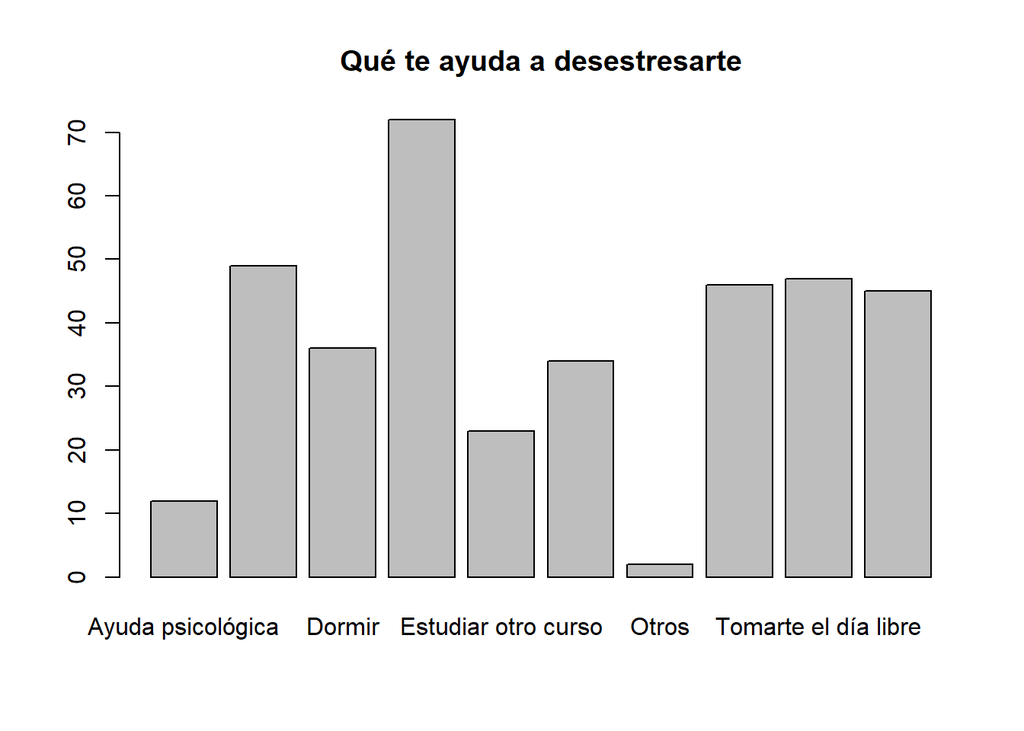

```r
barplot(table(unlist(datoSI$Desestresamiento)),main = "Qué te ayuda a desestresarte")
```

```r
kable(table(unlist(datoSI$Desestresamiento)))
```

| Var1 | Freq |
| --- | --- |
| Ayuda psicológica | 12 |
| Deporte | 49 |
| Dormir | 36 |
| Escuchar música | 72 |
| Estudiar otro curso | 23 |
| Maldecir al profesor y al curso | 34 |
| Otros | 2 |
| Pedir ayuda a tus compañeros | 46 |
| Tomarte el día libre | 47 |
| Videojuegos | 45 |

Con esta gráfica se buscó determinar las actividades que realizaban los alumnos para poder reducir el nivel de estrés. Es así que observamos que muy pocos buscaron ayuda psicológica, mientras que la gran mayoría se dedicó a actividades de ocio como escuchar música, jugar video juegos, tomarse el día libre o realizar agún deporte.

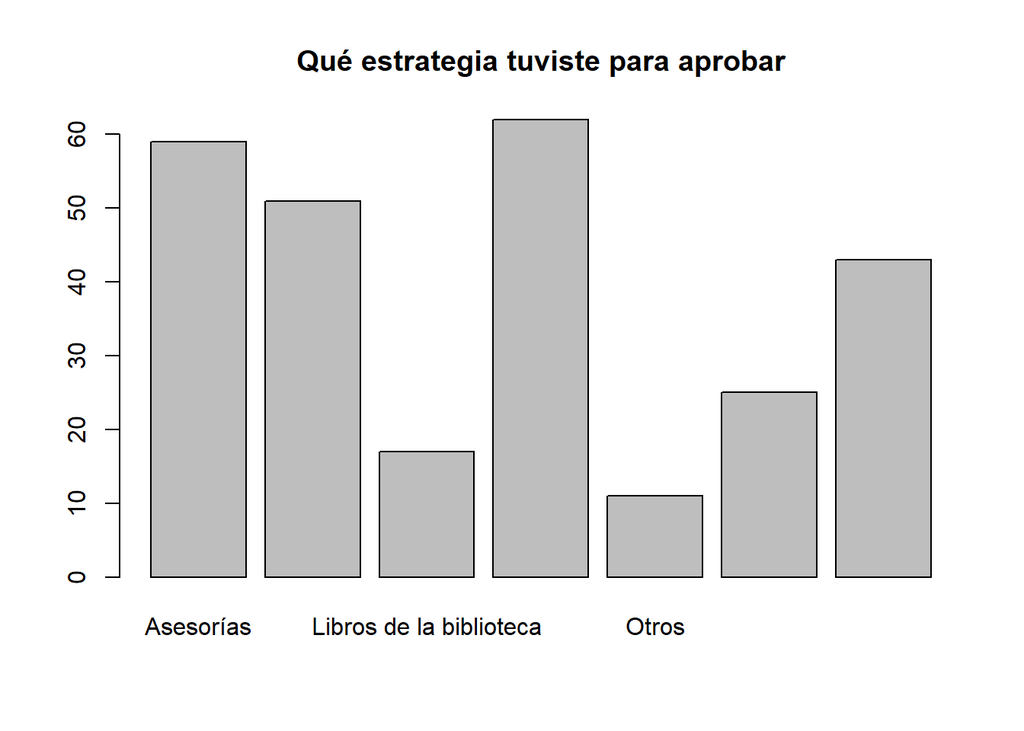

```r
barplot(table(unlist(datoSI$AprobarEstrategia)),main = "Qué estrategia tuviste para aprobar")
```

```r
kable(table(unlist(datoSI$AprobarEstrategia)))
```

| Var1 | Freq |
| --- | --- |
| Asesorías | 59 |
| Estudios grupales | 51 |
| Libros de la biblioteca | 17 |
| Mentorías | 62 |
| Otros | 11 |
| Profesor particular | 25 |
| Solo estudié lo aprendido en clase | 43 |

A partir de esta gráfica podemos observar que las técnicas aplicadas por los estudiantes para poder aprobar el curso fueron, en su gran mayoría, de asesorías, mentorías y estudios en grupo. Mientras que un grupo menor estudiaba solo en la biblioteca y otros con profesores particulares.

```r
# Convertir las columnas a tipo character
datoSI$HorasEstudios <- as.character(datoSI$HorasEstudios)
datoSI$HorasSueño <- as.character(datoSI$HorasSueño)
datoSI$HorasLibres <- as.character(datoSI$HorasLibres)

# Función para convertir horas en formato "HH:MM:SS" a número entero de horas
to_horas <- function(horas) {
  horas_separadas <- strsplit(horas, ":")
  horas_numericas <- sapply(horas_separadas, function(x) {
    as.numeric(x[1])
  })
  return(horas_numericas)
}

# Convertir las columnas a número entero de horas
datoSI$HorasEstudios <- to_horas(datoSI$HorasEstudios)
datoSI$HorasSueño <- to_horas(datoSI$HorasSueño)
datoSI$HorasLibres <- to_horas(datoSI$HorasLibres)

# Calcular la suma de las horas
datoSI$suma_horas <- datoSI$HorasEstudios + datoSI$HorasSueño + datoSI$HorasLibres

# Eliminar las filas que cumplan la condición
datoSIw <- datoSI[datoSI$suma_horas <= 24, ]

# Eliminar las columnas auxiliares
datoSI$suma_horas <- NULL
```

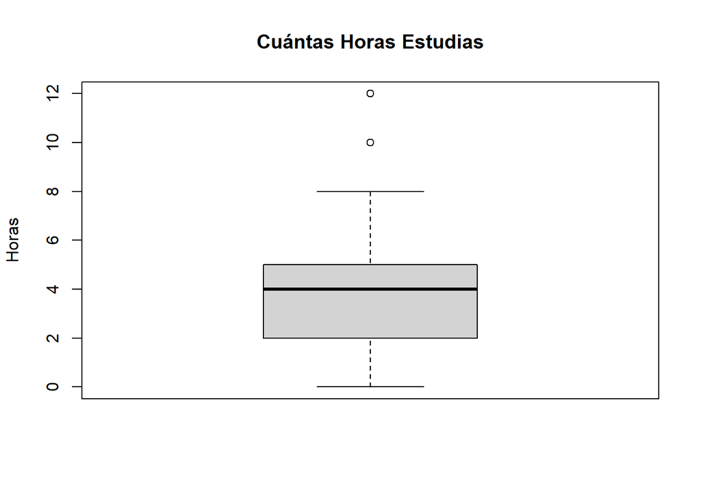

```r
boxplot(datoSIw$HorasEstudios, main = "Cuántas Horas Estudias", ylab = "Horas")
```

```r
cat("Promedio: ", mean(datoSIw$HorasEstudios),"\n")
```

```
## Promedio:  4.102041
```

```r
cat("Minimo: ", min(datoSIw$HorasEstudios),"\n")
```

```
## Minimo:  0
```

```r
cat("Maximo: ", max(datoSIw$HorasEstudios),"\n")
```

```
## Maximo:  12
```

```r
HE_cuartiles <- quantile(datoSIw$HorasEstudios, probs = c(0.25, 0.5, 0.75))
cat("Primer cuartil (Q1):", HE_cuartiles[1], "\n")
```

```
## Primer cuartil (Q1): 2
```

```r
cat("Mediana:", HE_cuartiles[2], "\n")
```

```
## Mediana: 4
```

```r
cat("Tercer cuartil (Q3):", HE_cuartiles[3], "\n")
```

```
## Tercer cuartil (Q3): 5
```

En el gráfico de caja podemos notar que el promedio de horas dedicadas al estudio del curso fue de aproximadamente 4 horas. Tenemos un máximo de 12 horas y mínimo de 0 horas. Notamos que en general no se dedicaron muchas horas semanales al estudio del curso.

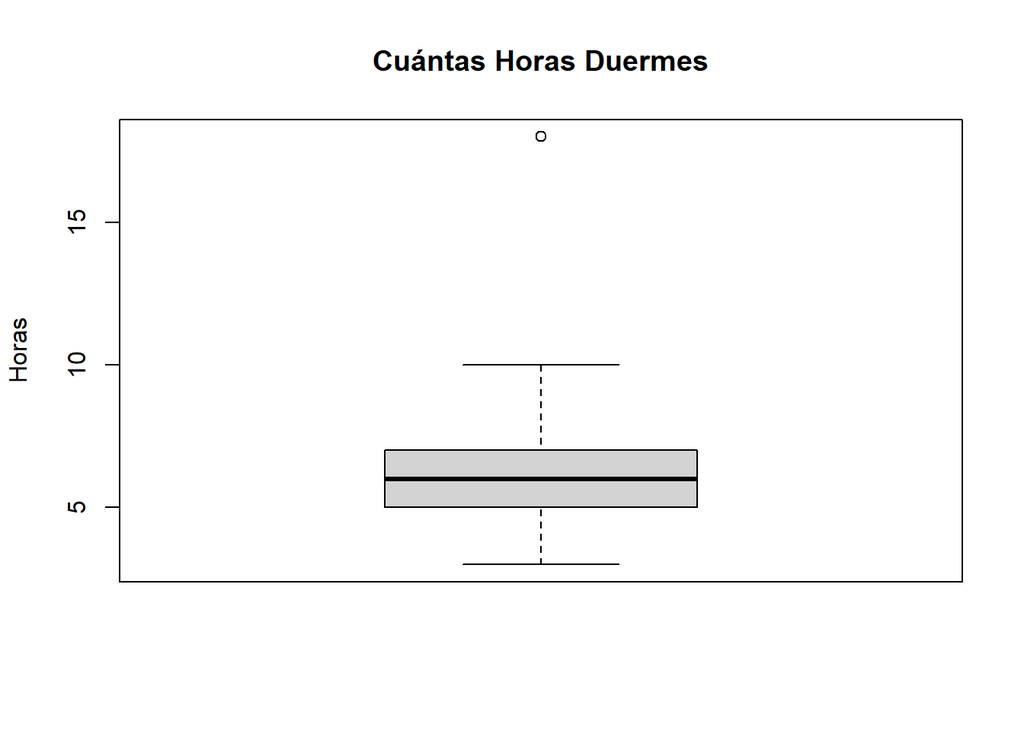

```r
boxplot(datoSI$HorasSueño, main = "Cuántas Horas Duermes", ylab = "Horas")
```

```r
cat("Promedio: ", mean(datoSIw$HorasSueño),"\n")
```

```
## Promedio:  6.122449
```

```r
cat("Minimo: ", min(datoSIw$HorasSueño),"\n")
```

```
## Minimo:  4
```

```r
cat("Maximo: ", max(datoSIw$HorasSueño),"\n")
```

```
## Maximo:  10
```

```r
HS_cuartiles <- quantile(datoSIw$HorasSueño, probs = c(0.25, 0.5, 0.75))
cat("Primer cuartil (Q1):", HS_cuartiles[1], "\n")
```

```
## Primer cuartil (Q1): 5
```

```r
cat("Mediana:", HS_cuartiles[2], "\n")
```

```
## Mediana: 6
```

```r
cat("Tercer cuartil (Q3):", HS_cuartiles[3], "\n")
```

```
## Tercer cuartil (Q3): 7
```

Como podemos observar aquí, el promedio de horas de sueño es de 6.12 horas. Por un lado tenemos un grupo que dormía como mínimo 4 horas al día y otro que dormía como máximo 10. Consideramos estos datos importantes, pues el estrés está relacionado mucho a cómo descansamos y distribuimos nuestros tiempos, ya que el descanso es importante para un mejor funciomaniento físico y mental.

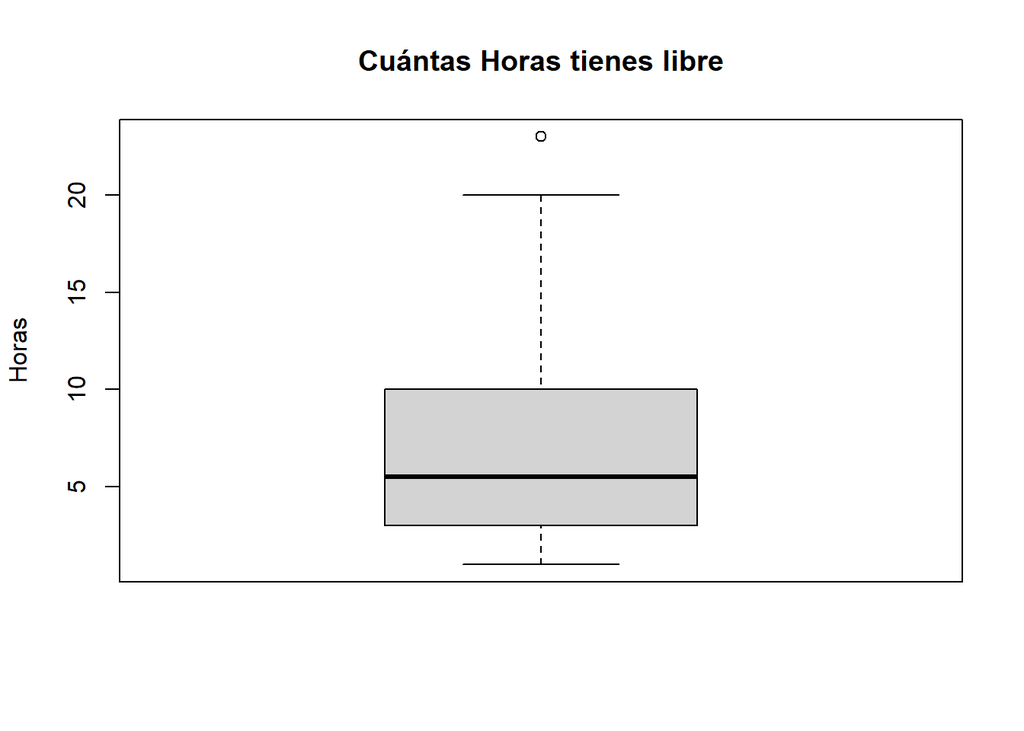

```r
boxplot(datoSI$HorasLibres, main = "Cuántas Horas tienes libre", ylab = "Horas")
```

```r
cat("Promedio: ", mean(datoSIw$HorasLibress),"\n")
```

```
## Promedio:  NA
```

```r
cat("Minimo: ", min(datoSIw$HorasLibres),"\n")
```

```
## Minimo:  1
```

```r
cat("Maximo: ", max(datoSIw$HorasLibres),"\n")
```

```
## Maximo:  15
```

```r
HL_cuartiles <- quantile(datoSIw$HorasLibres, probs = c(0.25, 0.5, 0.75))
cat("Primer cuartil (Q1):", HL_cuartiles[1], "\n")
```

```
## Primer cuartil (Q1): 3
```

```r
cat("Mediana:", HL_cuartiles[2], "\n")
```

```
## Mediana: 5
```

```r
cat("Tercer cuartil (Q3):", HL_cuartiles[3], "\n")
```

```
## Tercer cuartil (Q3): 8
```

De la misma manera, algo similar al análisis anterior, aquí observamos que en la cantidad de horas libres a la semana como mínimo era de 1 hora y un valor máximo de 15 horas. Una menor cantidad de horas de descanso puede influir directamente en los niveles de estrés que pueden darse en las personas.

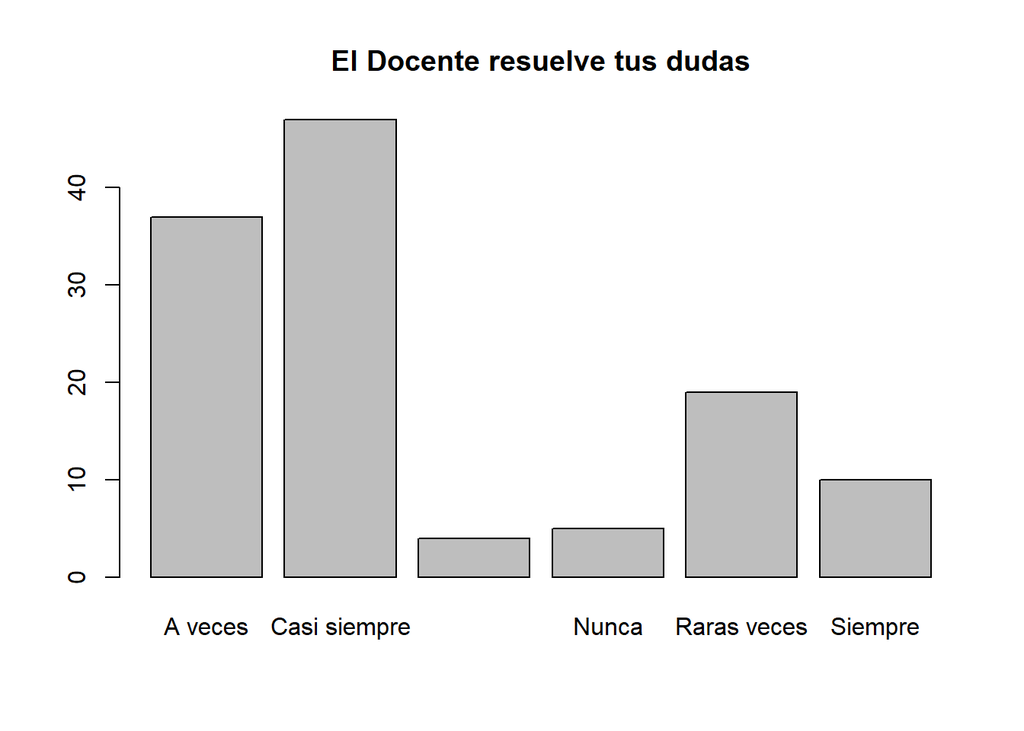

```r
ApyD <- table(datoSI$ApoyoDocente)
barplot(ApyD, main = "El Docente resuelve tus dudas")
```

```r
kable(ApyD)
```

| Var1 | Freq |
| --- | --- |
| A veces | 37 |
| Casi siempre | 47 |
| No les pregunté al respecto | 4 |
| Nunca | 5 |
| Raras veces | 19 |
| Siempre | 10 |

Con este gráfico buscamos identificar si una de las razones por las que se complica el curso se debe a si el profesor(a) del curso se toma el tiempo de resolver las dudas de los alumnos, esto porque no todos tienen la misma forma de entender un tema y muchas veces esto complica el entendimiento del curso, haciéndolo más díficil para algunos. Aquí observamos que el 38% de los encuestados mencionó que los profesores sí atendian a sus dudas y solo un 4% mencionaron que nunca recibieron apoyo.

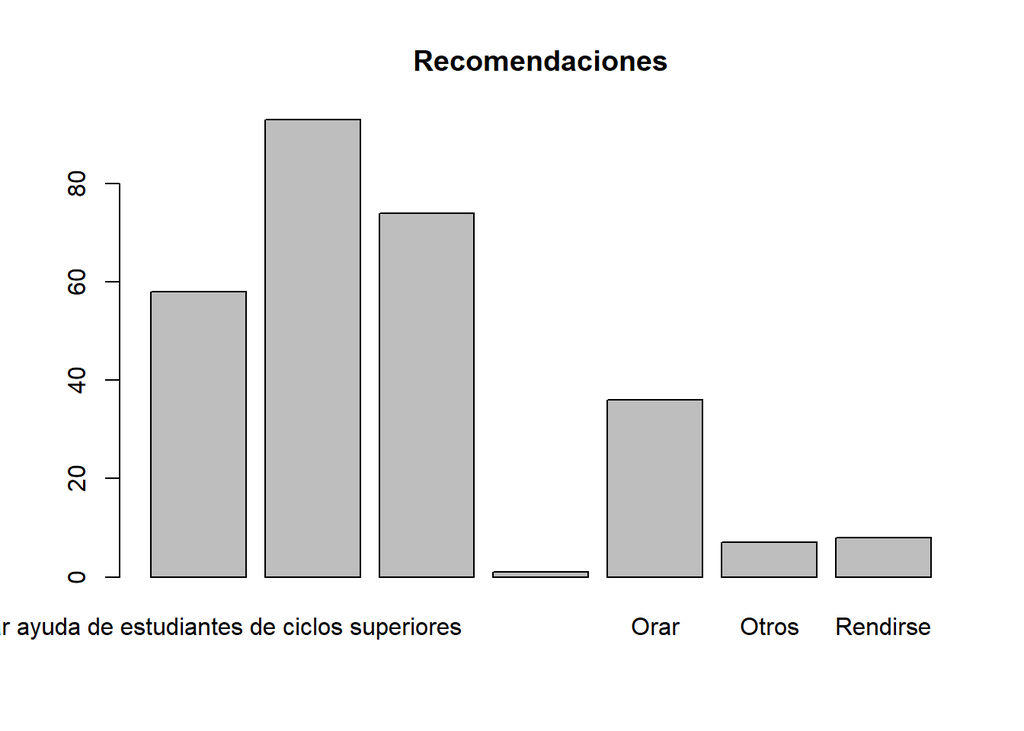

```r
barplot(table(unlist(datoSI$Recomendaciones)),main = "Recomendaciones")
```

```r
kable(table(unlist(datoSI$Recomendaciones)))
```

| Var1 | Freq |
| --- | --- |
| Buscar ayuda de estudiantes de ciclos superiores | 58 |
| Colocar el 100% de tu esfuerzo desde la primera semana | 93 |
| Estudiar de antemano el curso | 74 |
| No recomendar nada (el curso es fácil no hay necesidad de preparación) | 1 |
| Orar | 36 |
| Otros | 7 |
| Rendirse | 8 |

De este gráfico podemos mencionar que la gran mayoría de los que han llevado el curso y lo consideran estresante recomiendan a los nuevos a estudiar desde la primera semana y estudiar de antemano el curso para tener una base sólida con qué sobrellevarlo.

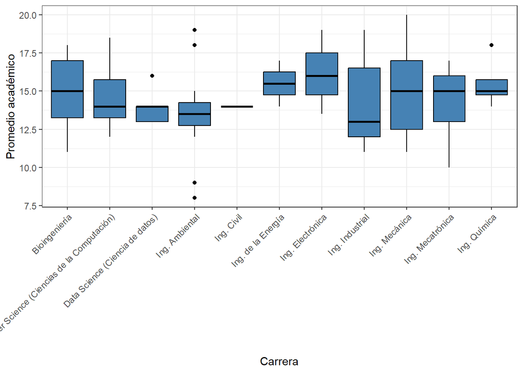

```r
library(ggplot2)

ggplot(datoSIs, aes(x = Carrera, y = Promedio)) +
  geom_boxplot(fill = "steelblue", color = "black") +
  labs(x = "Carrera", y = "Promedio académico") +
  theme_bw() +
  theme(axis.text.x = element_text(angle = 45, hjust = 1))
```

```r
aggregate(Promedio ~ Carrera, data = datoSIs, FUN = mean)
```

| Carrera | Promedio |
| --- | --- |
| Bioingeniería | 14.71429 |
| Computer Science (Ciencias de la Computación) | 14.39286 |
| Data Science (Ciencia de datos) | 14.00000 |
| Ing. Ambiental | 13.50000 |
| Ing. Civil | 14.00000 |
| Ing. de la Energía | 15.50000 |
| Ing. Electrónica | 16.16667 |
| Ing. Industrial | 14.28571 |
| Ing. Mecánica | 14.76667 |
| Ing. Mecatrónica | 14.60000 |

[output cut: 1 more lines]

De este gráfico de caja mostramos los promedios de notas de las diferentes carreras y podemos observar que en general casi todas las carrerar manejan el mismo promedio de notas para el curso, es decir ninguna predomina por mucho sobre las otras carreras. Podemos decir que el nivel del curso, sumado al estrés generado afectó de cierta manera a los promedios del curso, haciendo que en general sea de entre 13 y 16.

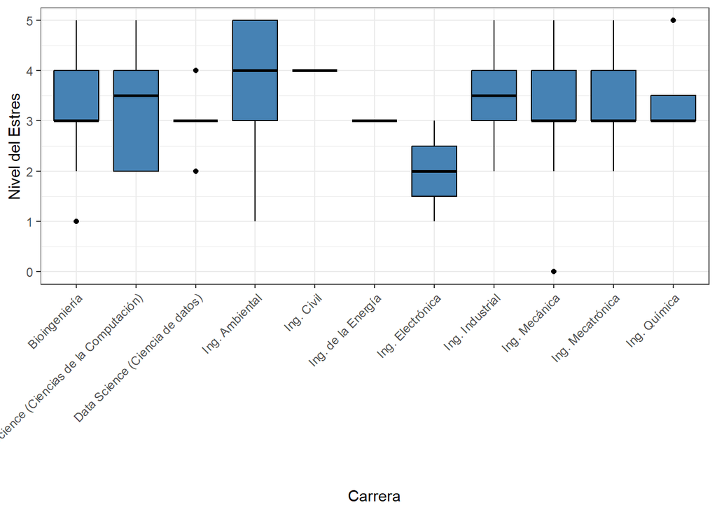

```r
ggplot(datoSI, aes(x = Carrera, y = NivelEstres)) +
  geom_boxplot(fill = "steelblue", color = "black") +
  labs(x = "Carrera", y = "Nivel del Estres") +
  theme_bw() +
  theme(axis.text.x = element_text(angle = 45, hjust = 1))
```

```r
aggregate(NivelEstres ~ Carrera, data = datoSI, FUN = mean)
```

| Carrera | NivelEstres |
| --- | --- |
| Bioingeniería | 3.294118 |
| Computer Science (Ciencias de la Computación) | 3.300000 |
| Data Science (Ciencia de datos) | 3.000000 |
| Ing. Ambiental | 3.666667 |
| Ing. Civil | 4.000000 |
| Ing. de la Energía | 3.000000 |
| Ing. Electrónica | 2.000000 |
| Ing. Industrial | 3.500000 |
| Ing. Mecánica | 3.352941 |
| Ing. Mecatrónica | 3.360000 |

[output cut: 1 more lines]

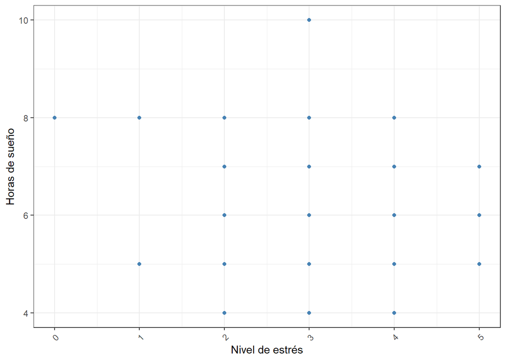

```r
grupo_estres <- aggregate(HorasSueño ~ NivelEstres, data = datoSIw, FUN = mean)

library(ggplot2)
ggplot(datoSIw, aes(x = NivelEstres, y = HorasSueño)) +
  geom_point(color = "steelblue") +
  labs(x = "Nivel de estrés", y = "Horas de sueño") +
  theme_bw() +
  theme(axis.text.x = element_text(angle = 45, hjust = 1))
```

```r
grupo_estres
```

| NivelEstres | HorasSueño |
| --- | --- |
| 0 | 8.000000 |
| 1 | 6.500000 |
| 2 | 6.210526 |
| 3 | 6.230769 |
| 4 | 5.863636 |
| 5 | 5.933333 |

Con esta gráfica buscamos determinar la relación entre horas de sueño y estrés. Notamos que, si bien hay una relación entre menor cantidad de horas de sueño con estrés muy alto, no es algo que sea un determinante, ya que hay quienes descansan unas 8 horas y también llegan a un nivel moderado de estrés (4). Posiblemente se deba también a otros factores y no solamente las horas de sueño.

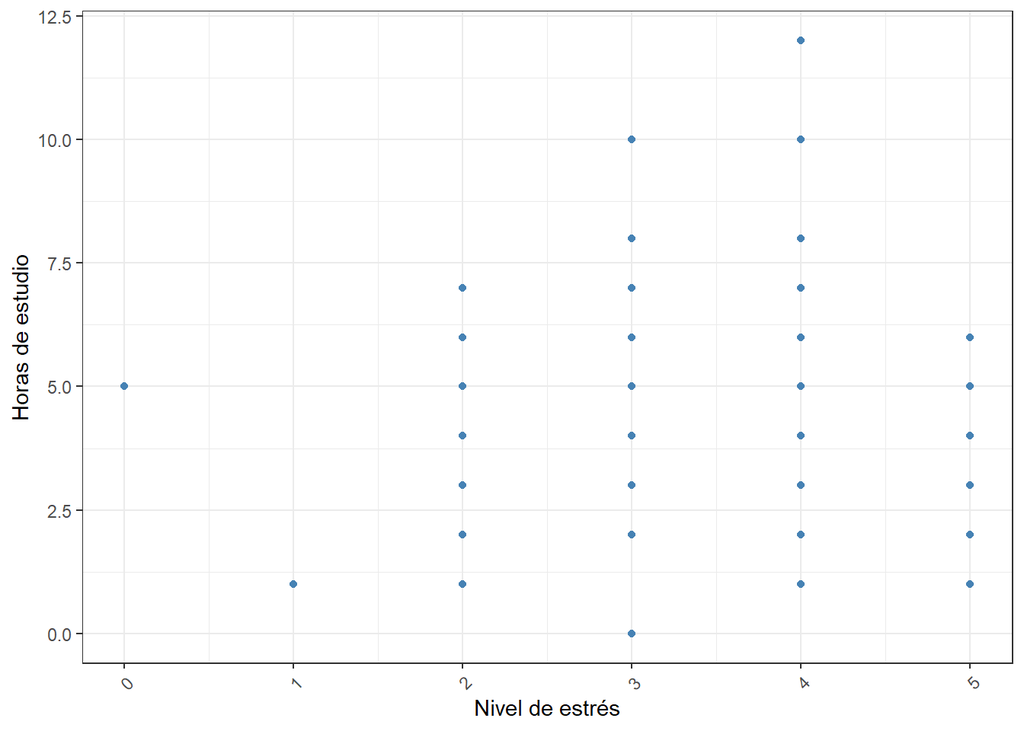

```r
grupo_estudio <- aggregate(HorasEstudios ~ NivelEstres, data = datoSIw, FUN = mean)

library(ggplot2)
ggplot(datoSIw, aes(x = NivelEstres, y = HorasEstudios)) +
  geom_point(color = "steelblue") +
  labs(x = "Nivel de estrés", y = "Horas de estudio") +
  theme_bw() +
  theme(axis.text.x = element_text(angle = 45, hjust = 1))
```

```r
grupo_estudio
```

| NivelEstres | HorasEstudios |
| --- | --- |
| 0 | 5.000000 |
| 1 | 1.000000 |
| 2 | 3.947368 |
| 3 | 4.205128 |
| 4 | 4.863636 |
| 5 | 3.266667 |

Aquí podemos notar que existe una relación entre las horas de estudio dedicadas al curso y niveles de estrés medio (3), moderado(4) y alto(5). Podríamos decir que muy a parte de estudiar un curso que genere estrés también es necesario realizar actividades para despejar la mente, así como también llevar una buena organización de métodos de estudio.

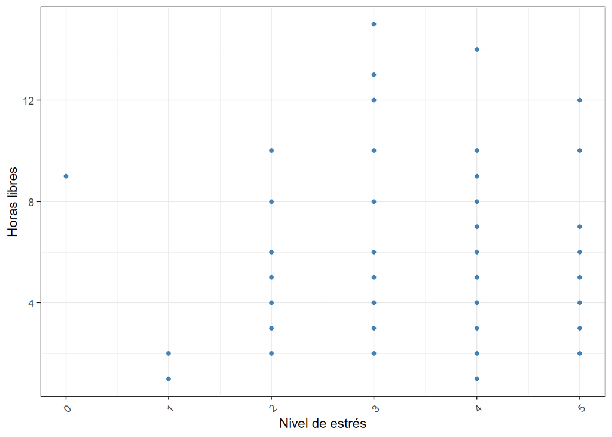

```r
grupo_libre <- aggregate(HorasLibres ~ NivelEstres, data = datoSIw, FUN = mean)

library(ggplot2)
ggplot(datoSIw, aes(x = NivelEstres, y = HorasLibres)) +
  geom_point(color = "steelblue") +
  labs(x = "Nivel de estrés", y = "Horas libres") +
  theme_bw() +
  theme(axis.text.x = element_text(angle = 45, hjust = 1))
```

```r
grupo_libre
```

| NivelEstres | HorasLibres |
| --- | --- |
| 0 | 9.000000 |
| 1 | 1.500000 |
| 2 | 5.473684 |
| 3 | 5.820513 |
| 4 | 6.045455 |
| 5 | 4.933333 |

Para este último gráfico podemos observar que las horas libres también están relacionadas a generar un cierto nivel de estrés; sin embargo, no podemos concluir que tener más horas libres te permita tener menos niveles de estrés. En este caso observamos que quienes tenían más horas libres presentaron un nivel de estres medio (3) y moderado (4). Quiere decir que el nivel del curso y la exigencia causaba ciertos niveles de estrés.